# Is class preference related to which hand you use to write?

Hanyu Zhong

# Is class preference related to which hand you use to write?

## Overview

This Exploratory Data Analysis focuses on the relationship between handedness and class choosing. One day I coincidentally found out that most of my friends who are left-handed are studying computer science or math. This makes me interested in the correlation between these two phenomenon. However, correlation does not mean causation. I wish to find out if my hypothesis is true or not, but not showing that class choosing is caused by handedness.

All data are collected by google form then transformed to google sheet. Most of the data are from students from Univerisyty of Richmond, and a minority of college stduents from other schools.

## Data dictionary

Here is a data dictionary for the left&right dataset:

- **timestamp**: This is the character variable that decribes the time when each individual survey was done. The format must be “MM/DD/YYYY HOUR:MINUTE:SECOND”.
- **gender**: This is a categorical variable that describes participants’ gender. Options are Female and Male.
- **type_of_class**: This is a charactervatiable that shows the majority subject participants are taking within a full academic year. Two or more subjects are connect with “&.”
- **handedness**: This is a categorical variable that describes which hand the participant uses most often. Options are left-handed, right-handed, and left and right handed.
- **scienceclass**: This is a numerical variable that describes the number of science and number related classes participants are taking within an academic year. If none, enter 0.
- **artshumanitiesclass**: This is a numerical variable that describes the number of arts and humanities classes participants are taking with in an academic year. If none, enter 0.

Which can be read in as follows:

| timestamp | gender | handedness | type_of_class | scienceclass | artshumanitiesclass |
| --- | --- | --- | --- | --- | --- |
| 2/11/2018 12:09:07 | Female | Right-handed | Science | 6 | 4 |
| 2/11/2018 12:26:01 | Male | Right-handed | Business | 6 | 3 |
| 2/11/2018 12:26:22 | Male | Right-handed | Business | 1 | 3 |
| 2/11/2018 12:41:37 | Female | Right-handed | Science | 3 | 1 |
| 2/11/2018 12:45:11 | Male | Right-handed | Theory | 3 | 6 |
| 2/11/2018 12:45:17 | Female | Right-handed | Economics&Math | 7 | 4 |
| 2/11/2018 12:52:17 | Female | Left-handed | Half and half | 2 | 2 |
| 2/11/2018 12:53:24 | Male | Right-handed | Economics | 4 | 1 |
| 2/11/2018 12:54:39 | Male | Right-handed | Business&Social Science | 3 | 2 |
| 2/11/2018 12:56:12 | Female | Left-handed | Arts&Humanity | 1 | 4 |

[output cut: 104 more lines]

## Exploratory Analysis

Graph 2 shows the correlation between the number of science classes and that of arts and science classes. Almost no correlation can be found in the graph because the points are almost spread out. The point in red is found as an outlier which should not be considered into the correlation calculation. The outlier has the number of classes that exceeds the normal value.

Graph 3 & 4 shows the diversity of topic students chosen with respect to their handedness.

Graph 5 & 6 shows the correlation between number of science classes and arts and humanities classes chosen with respect to different handedness.

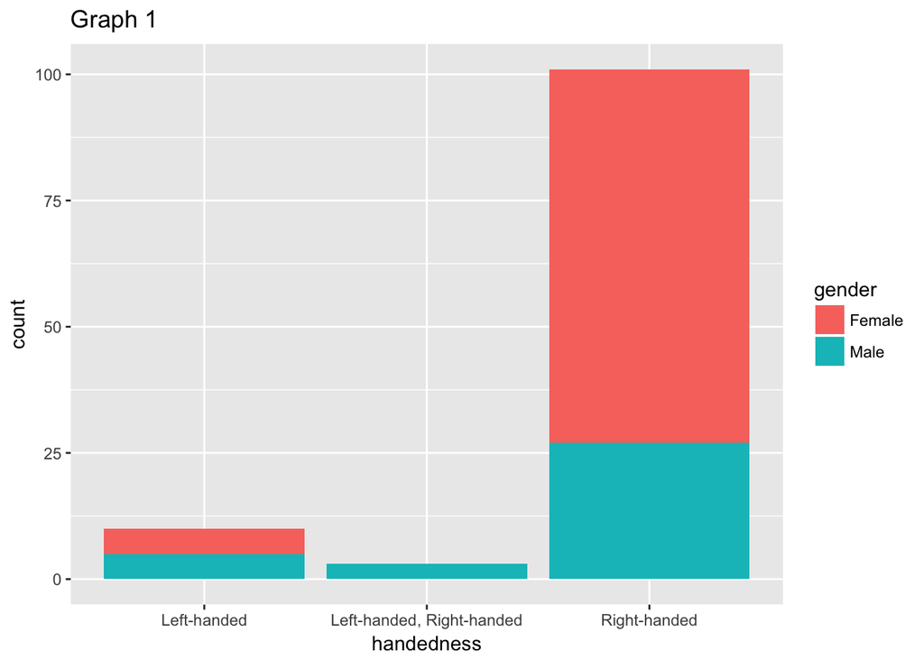

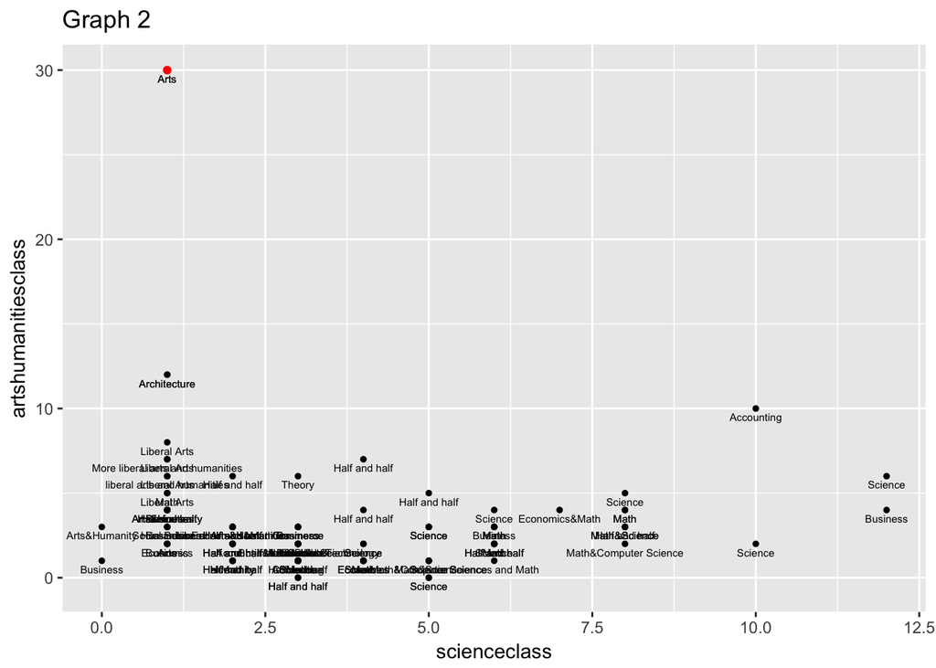

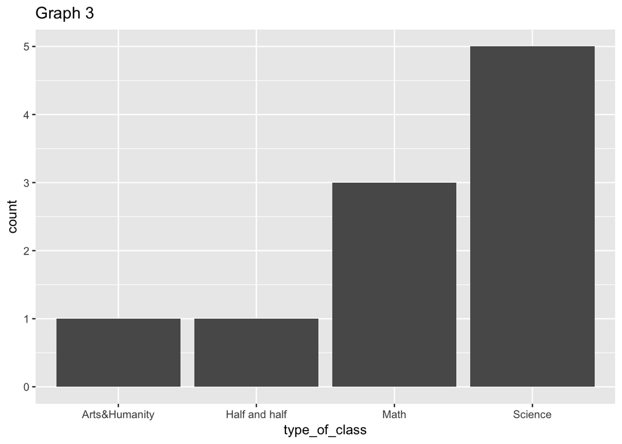

[figure not shown]

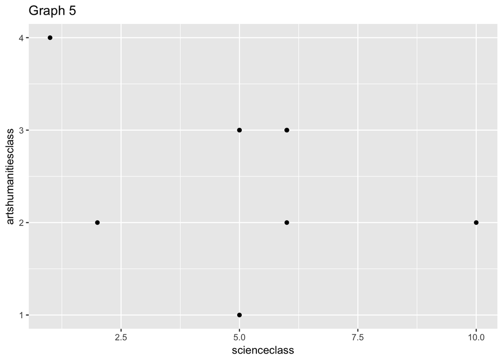

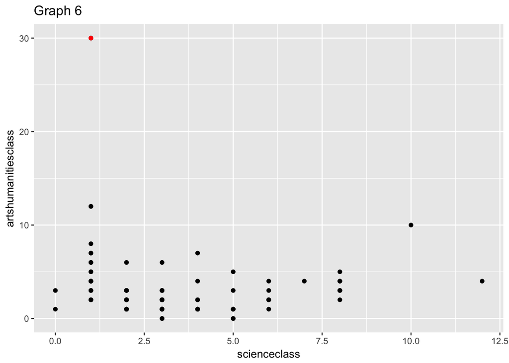

## References

All data are from my own survey “Left-handed or Right-handed?”: https://docs.google.com/forms/d/e/1FAIpQLSd2EQy-5xDHaO9QsvzUSwpE9PIb2hIkAmV2_pIqQ9CcAk-YBQ/viewform?usp=sf_link